# Making plots with `ggplot2`: histograms, boxplots, line graphs

# Violin Plot

A violin plot is yet another plot type used to show data distribution.

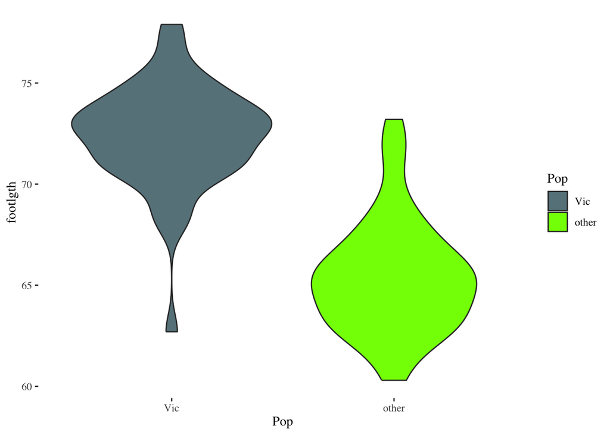

```r
# violin plot using geom_violin
ggplot(data=possum, aes(y=footlgth, x=Pop, fill=Pop)) +
  geom_violin() +
  scale_fill_manual(values=c("lightblue4", "chartreuse")) +
  theme_tufte()
```

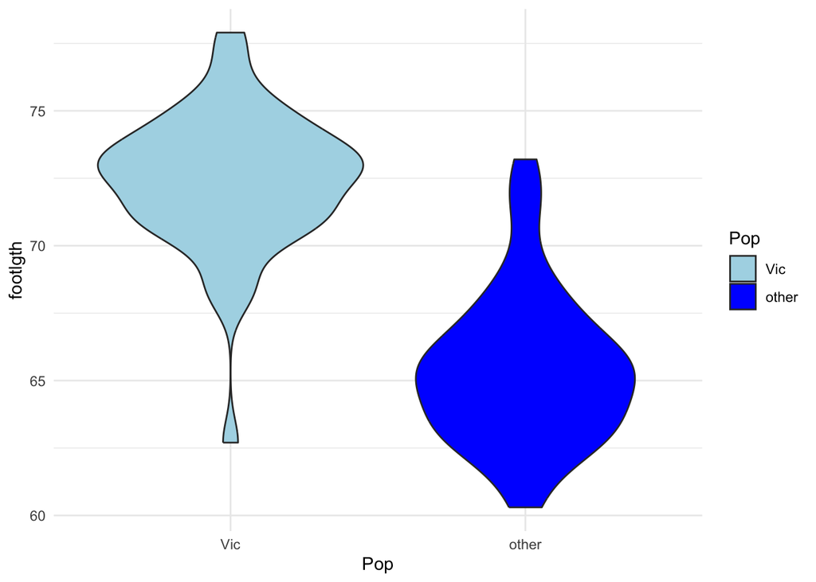

```r
# alter colors and theme
ggplot(data=possum, aes(y=footlgth, x=Pop, fill=Pop)) +
  geom_violin() +
  scale_fill_manual(values=c("lightblue", "blue")) +
  theme_minimal()
```

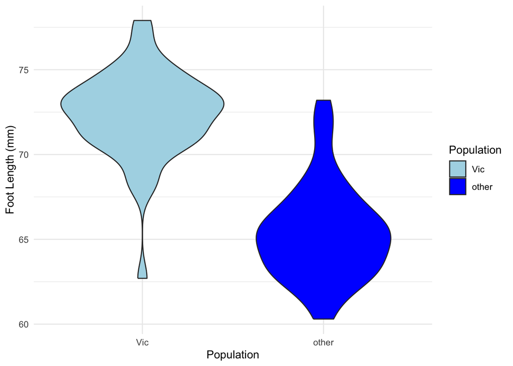

```r
# add labels
ggplot(data=possum, aes(y=footlgth, x=Pop, fill=Pop)) +
  geom_violin() +
  scale_fill_manual(values=c("lightblue", "blue")) +
  labs(x="Population", y="Foot Length (mm)",
       fill="Population") +
  theme_minimal()
```

**Tip**

Histograms, Boxplots, and Violin Plots are all different ways to visualize data distribution. Violin plots and Boxplots are especially good for comparing data distribution between groups.

## In class exersize

Choose one numeric variable from the possum dataset. Create two different distribution plots of that variable (choose from: histogram, density, boxplot, violin). Filter for only one of the populations and then compare across a different grouping variable (other than `Population`).

- Change the theme
- Change the colors

Then write 3–4 sentences:

- What do you see? (Be specific.)
- What does each plot make clearer?
- What does each plot hide or distort?

*There is a spot on the Homework for you to copy your work from this section.*